# Lab 2A - Classification

### 1. Load the Data

1. Import the OS library.

```python
import os
```

2. Set the working directory to "C:\Workshop\Data".

```python
os.chdir("C:\Workshop\Data")
```

3. Import the pandas library as "pd".

```python
import pandas as pd
```

4. Read the Iris CSV file into a data frame named *iris*.

```python
iris = pd.read_csv("Iris.csv")
```

### 2. Explore the Data

1. Inspect the *iris* data set with the `head` function.

```python
iris.head()
```

|  | Sepal_Length | Sepal_Width | Petal_Length | Petal_Width | Species |
| --- | --- | --- | --- | --- | --- |
| 0 | 5.1 | 3.5 | 1.4 | 0.2 | setosa |
| 1 | 4.9 | 3.0 | 1.4 | 0.2 | setosa |
| 2 | 4.7 | 3.2 | 1.3 | 0.2 | setosa |
| 3 | 4.6 | 3.1 | 1.5 | 0.2 | setosa |
| 4 | 5.0 | 3.6 | 1.4 | 0.2 | setosa |

2. Import the matplotlib.pyplot library as "plt".

```python
import matplotlib.pyplot as plt
```

3. Create a color palette containing three colors.

```python
palette = {
    'setosa':'#fb8072',
    'versicolor':'#80b1d3',
    'virginica':'#b3de69'}
```

4. Map the colors to each species of iris flower.

```python
colors = iris.Species.apply(lambda x:palette[x])
```

5. Create a scatterplot matrix of the *iris* data set colored by species.  
*Note: The semicolon at the end returns only plot and no text output.*

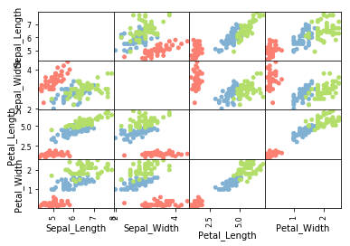

```python
pd.plotting.scatter_matrix(
    frame = iris,
    color = colors,
    alpha = 1,
    s = 100,
    diagonal = "none");
```

6. Create a scatter plot of petal width (*y*) vs. petal length (*x*).

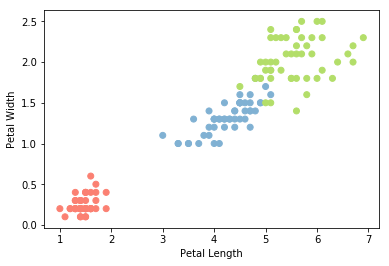

```python
plt.scatter(
    x = iris.Petal_Length,
    y = iris.Petal_Width,
    color = colors)
plt.xlabel("Petal Length")
plt.ylabel("Petal Width")
plt.show()
```

### 3. Transform the Data

1. Create a data frame named *X* containing all features (i.e. the first four columns).

```python
X = iris.iloc[:, 0:4]
```

2. Insect the features data frame *X* using the `head` function.

```python
X.head()
```

|  | Sepal_Length | Sepal_Width | Petal_Length | Petal_Width |
| --- | --- | --- | --- | --- |
| 0 | 5.1 | 3.5 | 1.4 | 0.2 |
| 1 | 4.9 | 3.0 | 1.4 | 0.2 |
| 2 | 4.7 | 3.2 | 1.3 | 0.2 |
| 3 | 4.6 | 3.1 | 1.5 | 0.2 |
| 4 | 5.0 | 3.6 | 1.4 | 0.2 |

3. Create a series named *y* containing the *Species* labels (i.e. the last column).

```python
y = iris.Species
```

4. Inspect the series of labels *y* using the `head` function.

```python
y.head()
```

```
0    setosa
1    setosa
2    setosa
3    setosa
4    setosa
Name: Species, dtype: object
```

### 4. Create the Training and Test Set

1. Import the numpy library as "np".

```python
import numpy as np
```

2. Set the random number seed to 123.

```python
np.random.seed(123)
```

3. Import the train_test_split function from sklearn.

```python
from sklearn.model_selection import train_test_split
```

4. Randomly sample 100 rows for the training set and 50 rows for the test set.

```python
X_train, X_test, y_train, y_test = train_test_split(
    X,
    y,
    train_size = 0.67,
    test_size = 0.33)
```

9. Inspect the shape of the training and test sets using their `shape` property.

```python
print("X_train: ", X_train.shape)
print("y_train: ", y_train.shape)
print("X_test:  ", X_test.shape)
print("y_test:  ", y_test.shape)
```

```
X_train:  (100, 4)
y_train:  (100,)
X_test:   (50, 4)
y_test:   (50,)
```

10. Question: How do you interpret these shapes in terms of columns and rows?

### 4. Predict with K-Nearest Neighbors

1. Import KNN classifier class from sklearn.

```python
from sklearn.neighbors import KNeighborsClassifier
```

2. Create a KNN model with k = 3.

```python
knn_model = KNeighborsClassifier(
    n_neighbors = 3)
```

3. Train the model using the training data.

```python
knn_model.fit(
    X = X_train,
    y = y_train)
```

```
KNeighborsClassifier(algorithm='auto', leaf_size=30, metric='minkowski',
           metric_params=None, n_jobs=1, n_neighbors=3, p=2,
           weights='uniform')
```

4. Predict the labels of the test set using the model.

```python
knn_predictions = knn_model.predict(X_test)
```

5. Create a confusion matrix for the predictions.

```python
pd.crosstab(
    y_test,
    knn_predictions,
    rownames = ['Reference'],
    colnames = ['Predicted'])
```

| Predicted Reference | setosa | versicolor | virginica |
| --- | --- | --- | --- |
| setosa | 20 | 0 | 0 |
| versicolor | 0 | 10 | 1 |
| virginica | 0 | 1 | 18 |

6. Import the accuracy_score function from sklearn.

```python
from sklearn.metrics import accuracy_score
```

7. Get the prediction accuracy.

```python
knn_score = accuracy_score(
    y_true = y_test,
    y_pred = knn_predictions)
```

8. Inspect the prediction accuracy.

```python
print(knn_score)
```

```
0.96
```

9. Visualize the knn predictions with correct prediction in black and incorrect predictions in red.

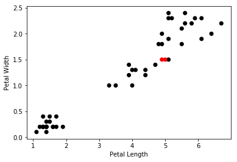

```python
plt.scatter(
    x = X_test.Petal_Length,
    y = X_test.Petal_Width,
    color = np.where(
        y_test == knn_predictions,
        'black',
        'red'))
plt.xlabel("Petal Length")
plt.ylabel("Petal Width")
plt.show()
```

10. Question: Why do you think these two points were misclassified?

### 5. Predict with a Decision Tree Classifier

1. Import the decision tree classifier from sklearn.

```python
from sklearn.tree import DecisionTreeClassifier
```

2. Create a decision tree classifier with max_depth = 3.

```python
tree_model = DecisionTreeClassifier(
    max_depth = 3)
```

3. Train the model using the training data.

```python
tree_model.fit(
    X = X_train,
    y = y_train)
```

```
DecisionTreeClassifier(class_weight=None, criterion='gini', max_depth=3,
            max_features=None, max_leaf_nodes=None,
            min_impurity_decrease=0.0, min_impurity_split=None,
            min_samples_leaf=1, min_samples_split=2,
            min_weight_fraction_leaf=0.0, presort=False, random_state=None,
            splitter='best')
```

4. Import the tree visualizer from sklearn.

```python
from sklearn.tree import export_graphviz
```

5. Visualize the decision tree.

```python
import graphviz
tree_graph = export_graphviz(
    decision_tree = tree_model,
    feature_names = list(X_train.columns.values),
    class_names = list(y_train.unique()),
    out_file = None)
graphviz.Source(tree_graph)
```

[figure not shown]

6. Question: Are you able to read and follow the logic of this decision tree?

7. Predict the labels of the test set with the model.

```python
tree_predictions = tree_model.predict(X_test)
```

8. Get the prediction accuracy.

```python
tree_score = accuracy_score(
    y_true = y_test,
    y_pred = tree_predictions)
```

9. Inspect the prediction accuracy.

```python
print(tree_score)
```

```
0.94
```

10. Visualize the prediction errors (in red).

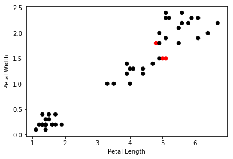

```python
plt.scatter(
    x = X_test.Petal_Length,
    y = X_test.Petal_Width,
    color = np.where(
        y_test == tree_predictions,
        'black',
        'red'))
plt.xlabel("Petal Length")
plt.ylabel("Petal Width")
plt.show()
```

### 6. Predict with a Neural Network

1. Import the standard scaler from sklearn.

```python
from sklearn.preprocessing import StandardScaler
```

2. Create a standard scaler.

```python
scaler = StandardScaler()
```

3. Fit the scaler to all training data (i.e. *X*).

```python
scaler.fit(X)
```

```
StandardScaler(copy=True, with_mean=True, with_std=True)
```

4. Scale the training and test set.

```python
X_train_scaled = scaler.transform(X_train)

X_test_scaled = scaler.transform(X_test)
```

5. Import the neural network classifier from sklearn.

```python
from sklearn.neural_network import MLPClassifier
```

```python
neural_model = MLPClassifier(
    hidden_layer_sizes = (4),
    activation = "tanh",
    max_iter = 2000)
```

7. Train the model using the training data.

```python
neural_model.fit(
    X = X_train_scaled,
    y = y_train)
```

```
MLPClassifier(activation='tanh', alpha=0.0001, batch_size='auto', beta_1=0.9,
       beta_2=0.999, early_stopping=False, epsilon=1e-08,
       hidden_layer_sizes=4, learning_rate='constant',
       learning_rate_init=0.001, max_iter=2000, momentum=0.9,
       nesterovs_momentum=True, power_t=0.5, random_state=None,
       shuffle=True, solver='adam', tol=0.0001, validation_fraction=0.1,
       verbose=False, warm_start=False)
```

8. Predict the test set labels using the model.

```python
neural_predictions = neural_model.predict(X_test_scaled)
```

9. Get the prediction accuracy.

```python
neural_score = accuracy_score(
    y_true = y_test,
    y_pred = neural_predictions)
```

10. Inspect the prediction accuracy.

```python
print(neural_score)
```

```
0.98
```

11. Visualize the prediction errors (in red).

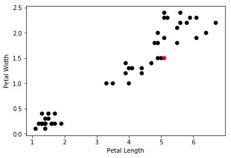

```python
plt.scatter(
    x = X_test.Petal_Length,
    y = X_test.Petal_Width,
    color = np.where(
        y_test == neural_predictions,
        'black',
        'red'))
plt.xlabel("Petal Length")
plt.ylabel("Petal Width")
plt.show()
```

### 7. Evaluate the Classifiers

1. Compare the accuracy of all three models.

```python
print("KNN: ", knn_score)
print("Tree:", tree_score)
print("NNet:", neural_score)
```

```
KNN:  0.96
Tree: 0.94
NNet: 0.98
```

2. Question: Which of these three classifiers would you choose? Why?